# Analyse de la variance à un facteur

Bruno Langlois

2025-11-04

## 1 $-$ Introduction

Le jeu de données `PlantGrowth` contient les résultats d’une expérience sur la croissance de plantes. Il comporte **3 groupes de traitement** (`ctrl`, `trt1`, `trt2`) et **la masse sèche des plantes** mesurée après la période expérimentale.

Le dataset contient 30 observations réparties également entre les trois groupes, ce qui rend le plan d’expérience équilibré.

Ce dataset est souvent utilisé pour illustrer des tests statistiques tels que l’ANOVA.

L’objectif est de comparer la croissance moyenne entre les trois groupes.

##### **■ Chargement du dataset `PlantGrowth`**

```r
data(PlantGrowth)
```

## 2 $-$ Exploration des données

```r
head(PlantGrowth)   # les premières lignes
```

```
##   weight group
## 1   4.17  ctrl
## 2   5.58  ctrl
## 3   5.18  ctrl
## 4   6.11  ctrl
## 5   4.50  ctrl
## 6   4.61  ctrl
```

```r
str(PlantGrowth)    # structure du dataset
```

```
## 'data.frame':    30 obs. of  2 variables:
##  $ weight: num  4.17 5.58 5.18 6.11 4.5 4.61 5.17 4.53 5.33 5.14 ...
##  $ group : Factor w/ 3 levels "ctrl","trt1",..: 1 1 1 1 1 1 1 1 1 1 ...
```

```r
summary(PlantGrowth) # résumé statistique
```

```
##      weight       group
##  Min.   :3.590   ctrl:10
##  1st Qu.:4.550   trt1:10
##  Median :5.155   trt2:10
##  Mean   :5.073
##  3rd Qu.:5.530
##  Max.   :6.310
```

##### ■ Comparaison des histogrammes

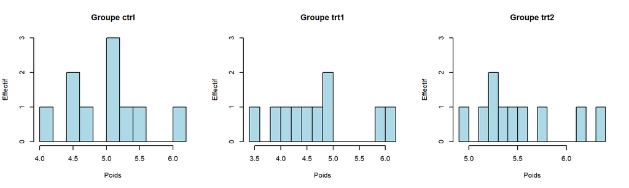

```r
par(mfrow = c(1,3))  # 1 ligne, 3 colonnes

for(g in unique(PlantGrowth$group)){
  hist(PlantGrowth$weight[PlantGrowth$group == g],
       main = paste("Groupe", g),
       xlab = "Poids",
       ylab = "Effectif",
       col = "lightblue",
       ylim = c(0, 3),
       breaks = 10)
}
```

##### ■ Poids moyen par groupe

```r
tapply(PlantGrowth$weight, PlantGrowth$group, mean)
```

```
##  ctrl  trt1  trt2
## 5.032 4.661 5.526
```

##### ■ Diagrammes en boîte

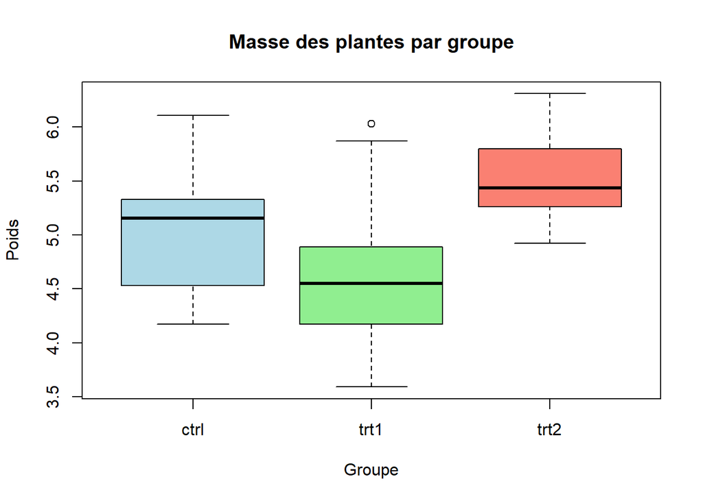

```r
boxplot(weight ~ group, data = PlantGrowth,
        main = "Masse des plantes par groupe",
        xlab = "Groupe",
        ylab = "Poids",
        col = c("lightblue", "lightgreen", "salmon"))
```

##### ■ Conclusion provisoire

Il ressort de l’analyse superficielle précédente que les poids moyens par groupes sont bien distincts (`trt1`<`ctrl`<`trt2`), et que les poids pour les groupes `trt1` et `trt2` sont presque séparés (75% des poids du groupe `trt1` sont inférieurs à tous les poids du groupe `trt2`) ; Le groupe `ctrl` semble à mi-chemin entre les deux autres.

Nous allons effectuer une ANOVA pour mesurer la significativité des différences observées précédemment.

## 3 $-$ ANOVA

#### ■ Analyse de la variance, significativité globale

```r
mod0<-lm(weight~group, data = PlantGrowth)
anova(mod0)
```

```
## Analysis of Variance Table
##
## Response: weight
##           Df  Sum Sq Mean Sq F value  Pr(>F)
## group      2  3.7663  1.8832  4.8461 0.01591 *
## Residuals 27 10.4921  0.3886
## ---
## Signif. codes:  0 '***' 0.001 '**' 0.01 '*' 0.05 '.' 0.1 ' ' 1
```

Le test de Fisher associé à l’ANOVA (qui met à l’épreuve l’hypothèse $H_0:\mu_{\text{ctrl}}=\mu_{\text{trt1}}=\mu_{\text{trt2}}$) révèle une p-value égale à 0.01591, donc inférieure à 0.05. On peut donc conclure qu’il existe au moins deux groupes dont les poids moyens diffèrent significativement au seuil de 5%.

#### ■ Régression avec `ctrl` comme modalité de référence

```r
summary(mod0)
```

```
##
## Call:
## lm(formula = weight ~ group, data = PlantGrowth)
##
## Residuals:
##     Min      1Q  Median      3Q     Max
## -1.0710 -0.4180 -0.0060  0.2627  1.3690
##
## Coefficients:
##             Estimate Std. Error t value Pr(>|t|)
## (Intercept)   5.0320     0.1971  25.527   <2e-16 ***
## grouptrt1    -0.3710     0.2788  -1.331   0.1944
## grouptrt2     0.4940     0.2788   1.772   0.0877 .
## ---
## Signif. codes:  0 '***' 0.001 '**' 0.01 '*' 0.05 '.' 0.1 ' ' 1
##
## Residual standard error: 0.6234 on 27 degrees of freedom
## Multiple R-squared:  0.2641, Adjusted R-squared:  0.2096
## F-statistic: 4.846 on 2 and 27 DF,  p-value: 0.01591
```

La p-value égale à 0.1944 (resp. 0.0877) est associée au test de l’hypothèse $H_0:\mu_{\text{ctrl}}=\mu_{\text{trt1}}$ (resp. $H_0:\mu_{\text{ctrl}}=\mu_{\text{trt2}}$). Au seuil de 5%, on ne peut donc pas rejeter $H_0$.  
Par conséquent, le groupe contrôle n’admet pas un poids moyen significativement différent de celui des deux autres groupes.

#### ■ Régression avec `trt1` comme modalité de référence

```r
mod1<-lm(weight~relevel(group,ref="trt1"), data = PlantGrowth)
summary(mod1)
```

```
##
## Call:
## lm(formula = weight ~ relevel(group, ref = "trt1"), data = PlantGrowth)
##
## Residuals:
##     Min      1Q  Median      3Q     Max
## -1.0710 -0.4180 -0.0060  0.2627  1.3690
##
## Coefficients:
##                                  Estimate Std. Error t value Pr(>|t|)
## (Intercept)                        4.6610     0.1971  23.644  < 2e-16 ***
## relevel(group, ref = "trt1")ctrl   0.3710     0.2788   1.331  0.19439
## relevel(group, ref = "trt1")trt2   0.8650     0.2788   3.103  0.00446 **
## ---
## Signif. codes:  0 '***' 0.001 '**' 0.01 '*' 0.05 '.' 0.1 ' ' 1
##
## Residual standard error: 0.6234 on 27 degrees of freedom
## Multiple R-squared:  0.2641, Adjusted R-squared:  0.2096
## F-statistic: 4.846 on 2 and 27 DF,  p-value: 0.01591
```

Sans surprise, pas de différence significativite entre les poids moyens des groupes `trt1` et `ctrl` (p-value correspondante égale à 0.19439>0.05). En revanche, les poids moyens des groupes `trt1` et `trt2` sont significativement différents (p-value correspondante égale à 0.00446<0.05).

#### ■ Confirmation avec le test des étendues de Tukey (HSD)

```r
TukeyHSD(aov(mod0))
```

```
##   Tukey multiple comparisons of means
##     95% family-wise confidence level
##
## Fit: aov(formula = mod0)
##
## $group
##             diff        lwr       upr     p adj
## trt1-ctrl -0.371 -1.0622161 0.3202161 0.3908711
## trt2-ctrl  0.494 -0.1972161 1.1852161 0.1979960
## trt2-trt1  0.865  0.1737839 1.5562161 0.0120064
```

Seule la p-value correspondant à la comparaison `trt2-trt1` (égale à 0.0120064) est inférieure à 0.05, ce qui confirme parfaitement l’analyse précédente.

## 4 $-$ Vérification des hypothèses du modèle

#### ■ Normalité des résidus

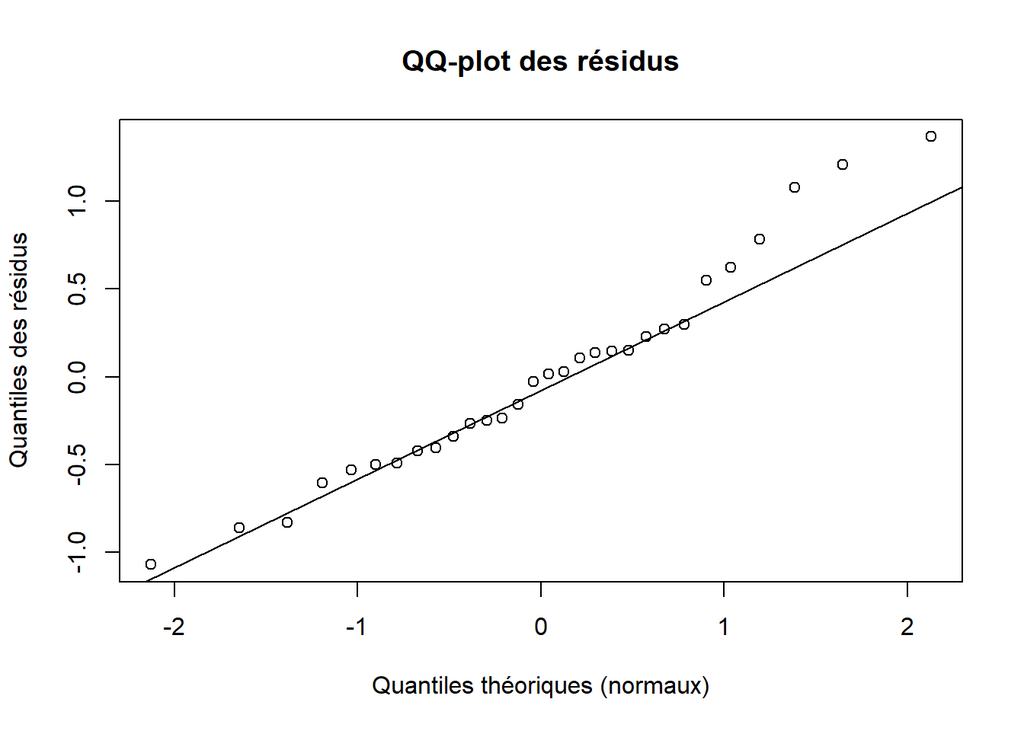

```r
res <- residuals(mod0)
qqnorm(res,
       main = "QQ-plot des résidus",
       xlab = "Quantiles théoriques (normaux)",
       ylab = "Quantiles des résidus")

qqline(res)
```

Le diagramme quantile-quantile (QQ-plot) des résidus montre un alignement global correct avec la droite de référence. On observe cependant un écart dans la queue supérieure, ce qui peut suggérer une déviation modérée par rapport à la normalité. Dans un échantillon de petite taille $(n = 30)$, de tels écarts ne sont pas rares ; nous complétons néanmoins avec un test de Shapiro-Wilk pour confirmer.

```r
shapiro.test(mod0$residuals)
```

```
##
##  Shapiro-Wilk normality test
##
## data:  mod0$residuals
## W = 0.96607, p-value = 0.4379
```

Le test de Shapiro-Wilk met à l’épreuve l’hypothèse nulle $H_0$ : les erreurs suivent une loi normale.  
La statistique $W$ est proche de 1 et la p-value (égale à 0.4379) est largement supérieure au seuil de 5 %. Nous ne rejetons donc pas $H_0$.  
Combiné au QQ-plot, ce résultat soutient l’hypothèse de normalité des erreurs : aucune déviation sérieuse n’est détectée.

#### ■ Homogénéité de la variance

L’hypothèse de normalité des erreurs étant admise, on peut donc utiliser le test de Bartlett qui met à l’épreuve l’hypothèse nulle $H_0$ : les variances du poids des trois groupes sont égales.

```r
bartlett.test(weight ~ group, data = PlantGrowth)
```

```
##
##  Bartlett test of homogeneity of variances
##
## data:  weight by group
## Bartlett's K-squared = 2.8786, df = 2, p-value = 0.2371
```

La p-value associée au test (égale à 0.2371) étant nettement supérieure au seuil de 5%, on ne rejette pas $H_0$, ce qui conduit à considérer plausible l’hypothèse d’égalité des variances (homoscédasticité).

## 5 $-$ Conclusion

Cette étude visait à comparer l’effet de trois traitements (contrôle, traitement 1 et traitement 2) sur la croissance de plantes, mesurée par leur masse sèche.

L’analyse de variance à un facteur indique que les traitements ont un effet significatif sur la croissance des plantes (ANOVA, p ≈ 0.016).

Les comparaisons post-hoc révèlent que :

Le traitement 2 (`trt2`) produit des plantes significativement plus lourdes que le traitement 1 (`trt1`) (p ≈ 0.012).

Le groupe contrôle (`ctrl`) occupe une position intermédiaire et ne diffère significativement ni de `trt1` (p ≈ 0.19) ni de `trt2` (p ≈ 0.088).

Les hypothèses du modèle apparaissent globalement respectées : les résidus ne montrent pas de déviation majeure par rapport à la normalité et les variances des groupes sont comparables.

En résumé : parmi les trois conditions expérimentales, le traitement 2 apparaît comme le plus favorable à la croissance des plantes, tandis que le traitement 1 semble donner des plantes plus légères. Le groupe contrôle se situe entre les deux, sans différence significative.